# Preliminary evaluation of alternative sablefishapportionment strategies

Kari Fenske, Curry Cunningham, Dana Hanselman

September 9, 2019

```
##    Equal Fixed
## 44    50    50
## 45    50    50
## 46    50    47
## 47    46    49
## 48    50    50
## 49    48    50
## 50    49    46
## 51    50    48
## 52    50    43
## 53    50    47
## 54    49    45
```

[output not shown]

```
## [1] 0 0 0 0 0 0
```

[output not shown]

[output cut: 170 more lines]

[output not shown]

[output cut: 69 more lines]

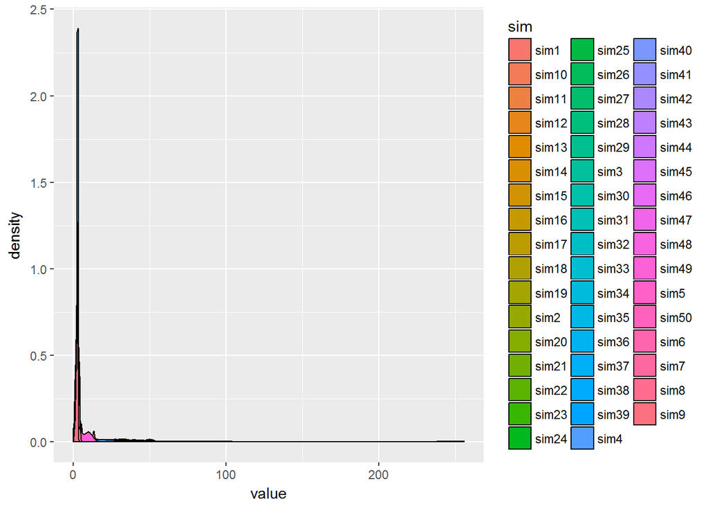

[output not shown]

[output cut: 110 more lines]

# Introduction and methods overview

Sablefish (Anoplopoma fimbria) in Alaska are managed on an Alaska-wide scale because movement rates among management regions are high and exploitation rates are sufficiently low. Each year the sablefish stock assessment model estimates ABC and OFL values that are subsequently apportioned to IFQ shareholders in six management regions. The combined ABC has been apportioned to regions using weighted moving average methods since 1993; these methods are intended to reduce the magnitude of inter-annual changes in the apportionment. However, apportionment of sablefish ABC among management regions has been fixed at 2013 recommended proportions since 2014 because the objective to reduce variability in apportionment was not being achieved. To evaluate apportionment strategies, we developed a spatial model to examine responses in sablefish biomass when different fishing mortalities occur among management regions.

An objective of the analyses presented in this document is to examine the performance of a suite of sablefish ABC apportionment methods. This document presents our apportionment simulation work to date. This is a work in progress and we are seeking feedback on operating model (OM) and estimation model (EM) design, alternative performance metrics that would be useful in comparing apportionment methods, developing recommendations, and any other suggestions for simulation and model performance.

These apportionment simulation analyses contain two primary components, a 6-area OM and a 1-area EM. The six areas correspond to the six sablefish management areas. The OM is written in R, and is spatial so that potential spatial dynamics in fleet or fish behavior (via catchability, selectivity, and fish movement) may be simulated. The OM simulates data in two periods - a deterministic conditioning period which occurs for years 1977-2018 and is the same across simulations, and a stochastic forward projecting portion which runs for years 2019-2029. The EM is similar to the EM used for sablefish management, but begins in 1977 instead of 1960, does not include length compositions, and does not fit a trawl survey. After the conditioning period data is generated by the OM, the OM population is sampled, and the simulated data is combined into a single area dataset which is passed to the EM.

In the forward projecting period, the OM-EM is iterative, looping through years. The order of operations for year y are:  
1. OM - Read in previous year’s apportioned ABC by area  
2. estimate the F required to catch ABC for each area  
3. apply F and M to OM population  
4. move fish between areas  
5. sample the population for fishery and longline survey abundance indices and for longline survey and fixed gear fishery age compositions  
6. build the data file and pass it to the EM in AD Model Builder  
7. run the EM (fit the simplified assessment model to simulated data) and get an estimate of the next year’s ABC (then repeat for the next year).

For each apportionment method examined, we are running 50 simulations covering years 1977-2029. For November, we hope to present results for 100 (or more) simulated datasets each looping over years 2019-2049, which will provide a 30-year forward outlook.

## Alternative apportionment scenarios examined

In the analyses presented in this document we examine 2 apportionment methods: Equal, Fixed. A summary of each apportioment method is below.  
1 - Equal: Each region receives 1/6 of the ABC.  
2 - Fixed: The apportionment proportions from the 2013 assessment that have been applied as fixed proportions for 2014-2018.  
3 - Equilibrium: Proportions in each area are based on the stationary distribution of the movement rates.  
4 - NPFMC: A 5-yr exponentially weighted moving average of fishery and survey indices; survey weight is 2x fishery weight (NPFMC accepted method, used 2000-2013).  
5 - Exp_survey_wt: Similar to ‘NPFMC’ option but using survey index only.  
6 - Exp_fishery_wt: Similar to ‘NPFMC’ option but using fishery index only.  
7 - Non-Exp_NPFMC: A 5-yr moving average of fishery and survey indices.  
8 - Partial_fixed: BS and AI receive 10% of the ABC each, WG, CG, WY, and EY are apportioned based on NPFMC method.  
9 - Age_based: Based on the proportions of fish at age of 50% maturity in each area - i.e. areas with greater proportion of fish at age of 50% maturity or greater will be apportioned a greater proportion of ABC.  
10 - Term_LLsurv: Terminal year of longline survey (no exponential weighting).

## Performance metrics and simulation summary results

Please note that these results are PRELIMINARY and should not be used for decision-making. OM and EM specifications are still being refined based on Plan Team and other feedback.

There are several key concerns regarding apportionment which we are examining and they can be loosely grouped into broader (yet still related) categories of 1) sustainability, 2) stability, and 3) value.

### Sustainability

The sustainability of the sablefish population is a primary concern and we evaluate how different methods of apportioning perform with respect to a B40 biological reference point.

For each year, simulation, and apportionment method we calculate the SSB(end_year)/B40 from the EM. The NPFMC harvest control rule is designed to limit fishing mortality when SSB(end_year)/B40 falls below 1. The apportionment methods all perform similarly with respect to SSB(end_year)/B40, which suggests the harvest control rule is functioning as intended. The large number of outliers may be due simulations which are crashing or not converging (and have not been removed from analyses at this point).

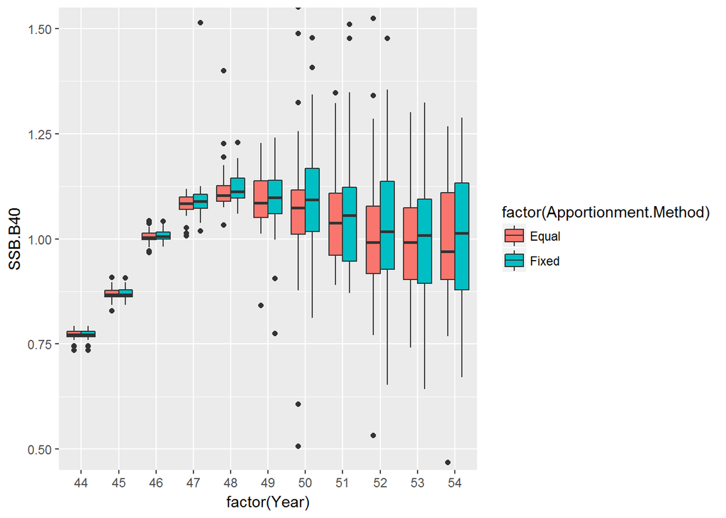

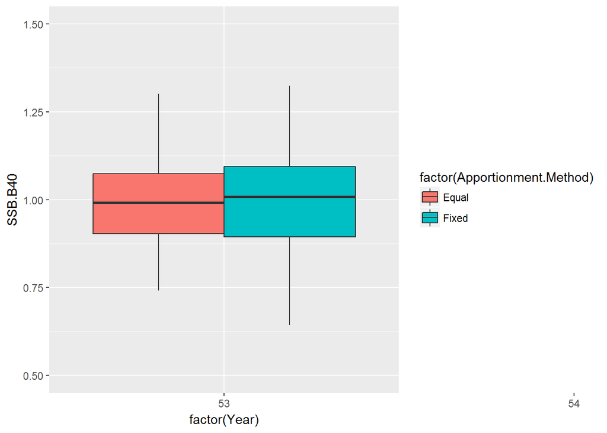

Depletion, as used here, is defined as the spawning biomass in the terminal year of each EM run relative to the spawning biomass in the EM starting year. For these simulations, the EM starting year is 1977 and end years range from 2019-2029. Note that 1977 is not virgin biomass so ‘depletion’ in this context provides relative information between methods, but should not be confused as a reduction from an unfished state.

```
##        Equal     Fixed
## 44 0.3830925 0.3830925
## 45 0.4324645 0.4357130
## 46 0.4926890 0.4952255
## 47 0.5186165 0.5257640
## 48 0.5217220 0.5224235
## 49 0.5242925 0.5245015
## 50 0.5124565 0.5109395
## 51 0.4945395 0.4953765
## 52 0.4750560 0.4742315
## 53 0.4671645 0.4755780
## 54 0.4552760 0.4416350
```

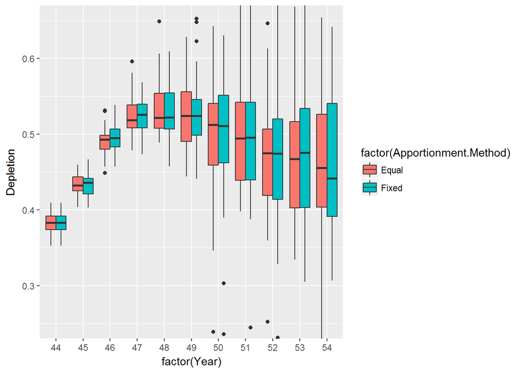

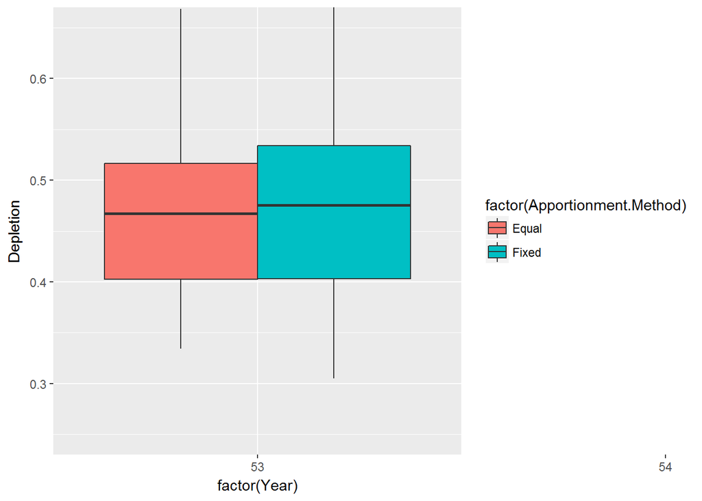

Because we have a single area stock assessment, we do not currently have estimates of sablefish biomass or spawning stock biomass in each management area, though the longline survey may give us a reasonable estimate. Since this is a simulation, we can, however, examine how well each apportionment method tracks the ‘true’ (simulated) population’s spawning stock biomass in each management area.

This is the mean relative percent difference between ‘true’ spawning stock biomass proportions and proportion of ABC by area for each apportionment method. Low values are good if we want apportionment to track the underlying population spawning stock biomass by area.

```
##        Equal Fixed
## BS     102.4  56.3
## AI      63.2  36.6
## WGOA    43.0   3.8
## CGOA   -53.9   9.4
## WY       4.3 -32.0
## EY-SEO -53.6 -30.5
```

Taking the average across spatial areas gives a single value for how well each apportionment method matches underlying spawning stock biomass. Again, lower values mean a better match to ‘true’ spawning population. If there are benefits to maintaining spawning biomass in all spatial areas (i.e. if there were spatial differences in fecundity that we are not aware of), an apportionment method with a low value here would be better.

```
## Equal Fixed
##  17.6   7.3
```

### Variability in ABC from year to year

```
## Equal Fixed
## -2.49 -2.27
```

```
##        Equal Fixed
## BS     -6.59 -2.52
## AI     -3.76 -2.12
## WGOA   -5.68 -2.47
## CGOA    5.51 -2.24
## WY     -5.10 -1.85
## EY-SEO  0.68 -2.43
```

This reflects what an individual management area may experience in terms of average change in ABC from year to year for each apportionment method. Higher values mean more change in ABC from year to year.

### Sablefish value and other considerations (*from a non economist)

The standardized mean ABC for each apportionment method combines data across years, fleets (a.k.a. gears), areas, and simulations for 2019-2029.

```
##     Equal     Fixed
## 0.7810883 1.2189117
```

Mean ABC apportioned to each management area (mean of all years and simulations) under the different apportionment methods is a key output of interest. The next figure shows mean ABC values, by area, for each apportionment method.

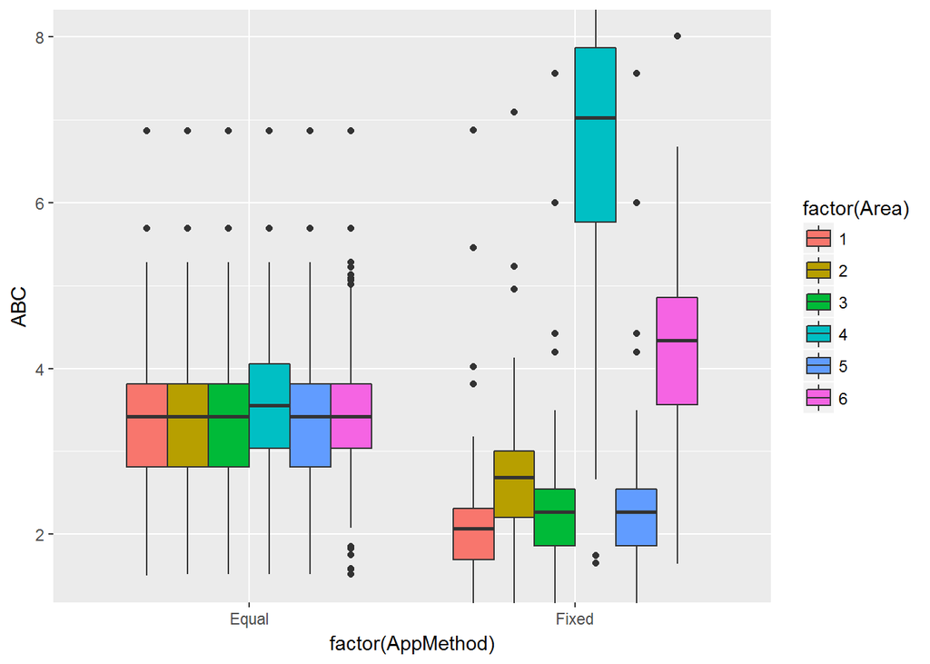

Next we examine the proportion of years and simulations where apportioned ABC summed over areas is above a specified threshold value. It is simple to change the threshold value being evaluated; the present value of the ABC threshold for management areas combined is 12 kilotons.

The proportion of years and simulations where total ABC is above the all-area threshold (12 kt) is:

```
## Equal Fixed
##  0.97  0.96
```

It may also be of value to set a threshold for individual management areas. We are presenting results for a threshold of 2 kilotons for each management area.

```
##        Equal Fixed
## BS      0.88  0.56
## AI      0.97  0.90
## WG      0.88  0.66
## CG      0.97  0.97
## WY      0.88  0.66
## EY/SEO  0.97  0.97
```

Other metrics of interest that are not yet coded include:  
mean age of fish in each management area (from the OM)  
mean age of catch in each management area (from the OM data)  
value of catch in each management area (using apportioned ABC, OM fishery age comp for each area to convert catch biomass to size, some estimate of mean ‘price’ or ‘value’ at size)

```
## [1] 54 30  6 50  2
```

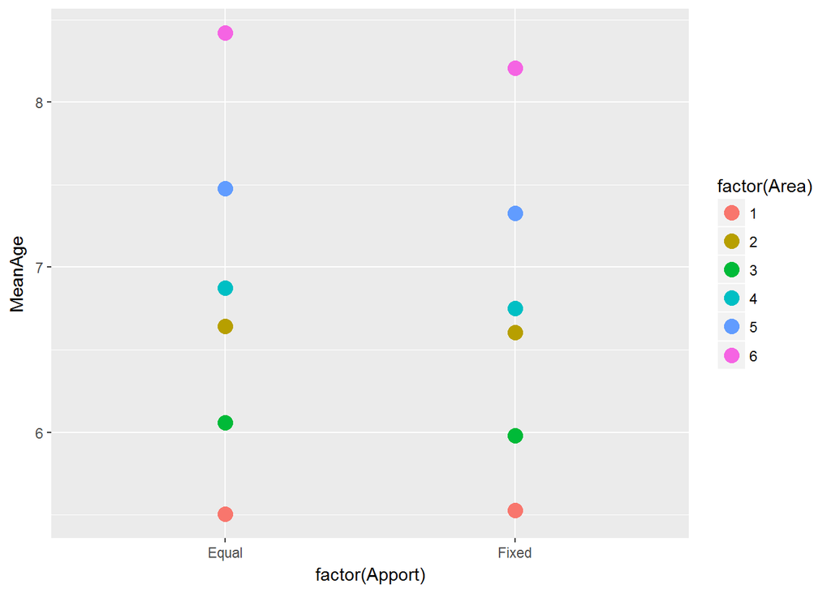

What are additional metrics that should be included in analyses for November Plan Team?

# Further details on OM and EM, model validation figures, and more output

# OM Conditioning period

The OM model begins by establishing initial numbers at age for each area in 1976. Initial N for 1976 is input as the 2018 management EM total abundance estimated for 1977. This is split into 6 spatial areas using the proportion of abundance by area from the longline survey abundance estimate and split into initial age and sex proportions using proportion by sex and age from 2018 management EM for 1976 numbers at age. Numbers at age are converted to biomass at age using the age-weight relationship as described in the sablefish 2018 SAFE report.

The OM conditioning period is deterministic and thus is the same for all simulations. Movement rates are specified between all 6 areas and the OM is set up to accommodate age-based movement, however, at present movement is age-invariant. During the OM conditioning period, recruitment is input as values from the management EM, catch is input, and the F which generated that catch is estimated and applied to the population. Please see the Appendix 2 for OM population dynamics equations.

Movement rates used in the OM are externally estimated using the methods from the Hanselman et al. (2015) sablefish movement paper, which uses 30+ years of tag release and recapture data. The model described in the paper was re-run for 6 areas and those movement values are input to the OM.

Table 1: Movement rates used in the OM are based on 30+ years of tag release and recapture data, as detailed in Hanselman et al. (2015).

```
##         To EY To WY To CG To WG To BS To AI
## From EY  0.74  0.08  0.15  0.03  0.00  0.00
## From WY  0.14  0.19  0.48  0.15  0.02  0.02
## From CG  0.11  0.19  0.49  0.16  0.03  0.02
## From WG  0.04  0.12  0.32  0.29  0.12  0.11
## From BS  0.01  0.03  0.09  0.22  0.63  0.03
## From AI  0.00  0.01  0.05  0.11  0.05  0.78
```

## Conditioning period validation

The figures and tables below are presented to show the ability of the spatial OM within the conditioning period to match the current EM historical data, and to further describe the methods for setting up the OM. In general, the OM results for the conditioning period provide a good match to estimates from the most recent stock assessment (“Management EM”, Hanselman et al. 2018). However some differences exist due to movement, the initial conditions specification, and spatial OM parameters which differ from the management EM. Because this isn’t a full MSE, alternative states of nature are not examamined here.

Abundance in numbers, biomass, and spawning biomass generated from the OM generally matches the Management model EM quite closely (Figures 1-3). However, the current runs being shown reduce the 2014 OM recruitment from 150 million recruits to 50 million recruits to help improve model convergence and to reduce incidences of crashing. This reduction is evident in the comparison figures below.

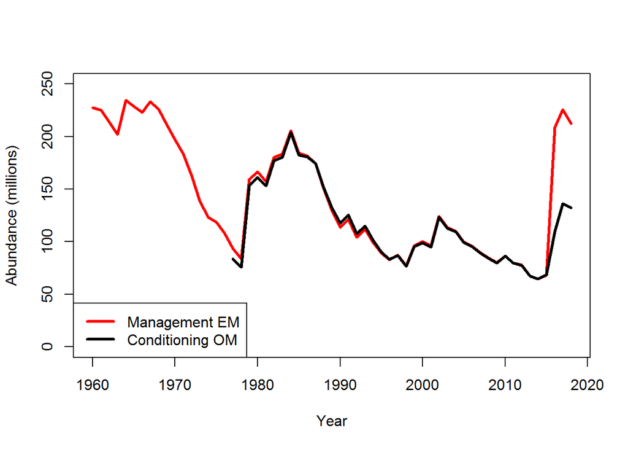

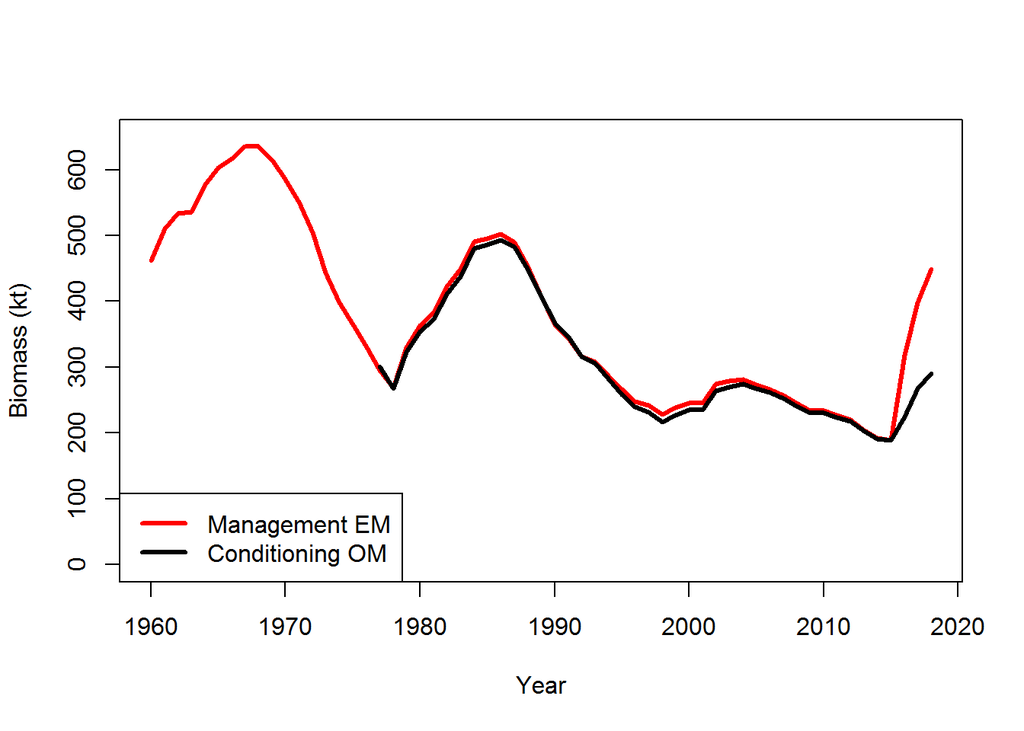

Figure 2: Biomass (kt, summed over areas) generated from the OM compared to the Management model EM.

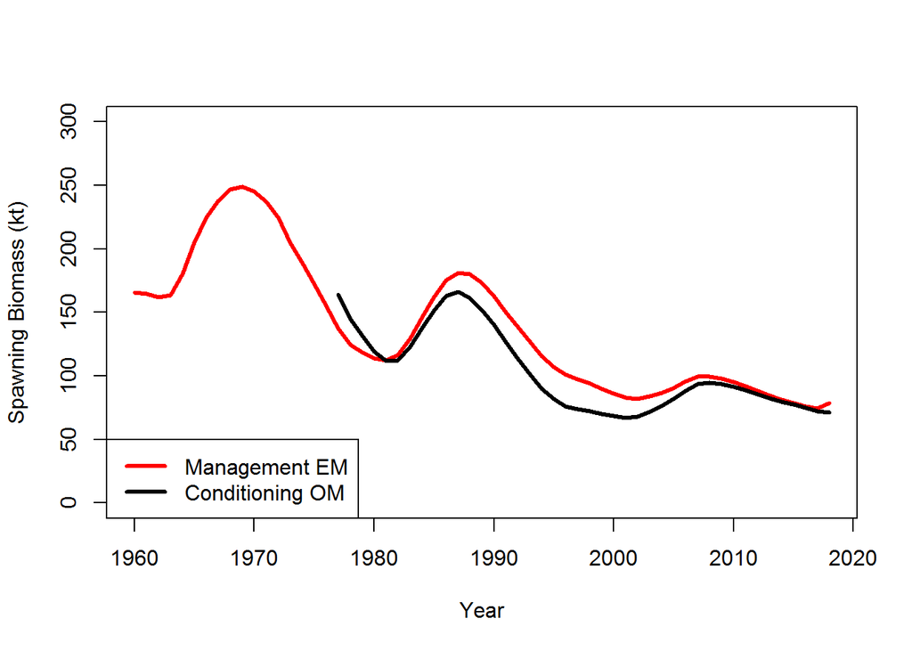

Figure 3: Spawning biomass (kt, summed over areas) generated from the OM compared to the Management model EM.

OM catch was designed to match Management EM observed catch. An F-solving function in the OM takes input catch by gear/fleet, area, and year and estimates the fishing mortality required to realize that level of catch, using OM numbers at age and selectivity. The estimated F rate is then used to simulate abundance in the next year of an OM iteration.

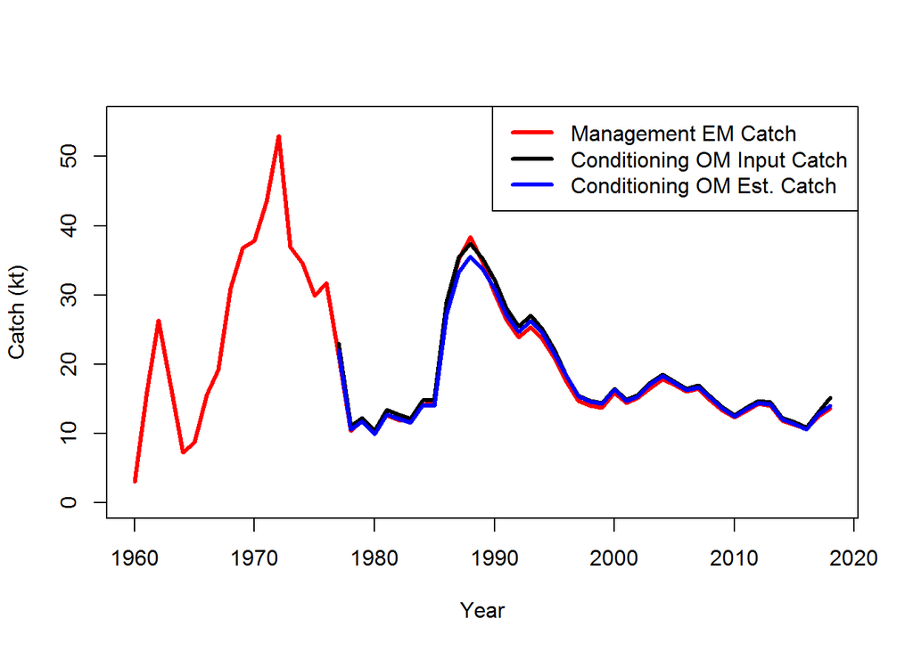

Figure 4: Catch (kt) for the Management EM, the input catch values for the OM, and the estimated OM catch values.

OM recruitment for the conditioning period was designed to match EM recruitment. Management EM recruitment values (in numbers) for 1977-2018 are input and split into 6 areas based on the average proportion of age-2 sablefish in each area of the longline survey, and also split equally between males and females (see equations in Appendix 2).

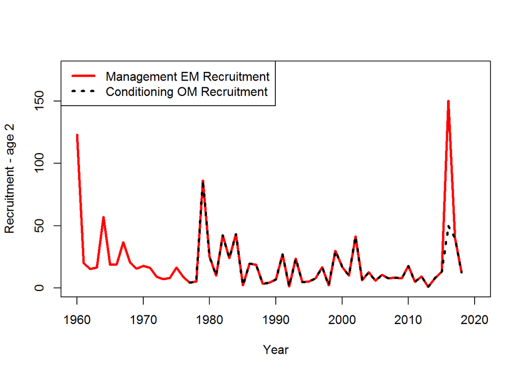

Figure 5: OM and EM recruitment for the conditioning period (in millions of fish) for all management areas summed are identical by design, except for the 2014 year class which we reduced in the OM to improve convergence in the forward simulation period.

Table 2: These values for age-2 proportions by area from the longline survey are used to split recruitment into spatial areas.

[output not shown]

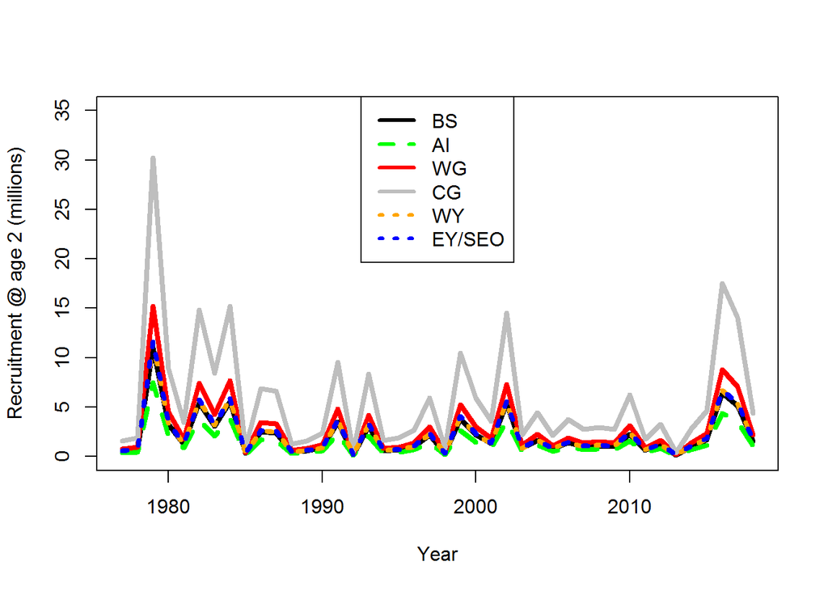

Figure 6: The resulting recruitment of age-2 fish to each management area for the conditioning period, after splitting into spatial areas using the proportions in Table 2.

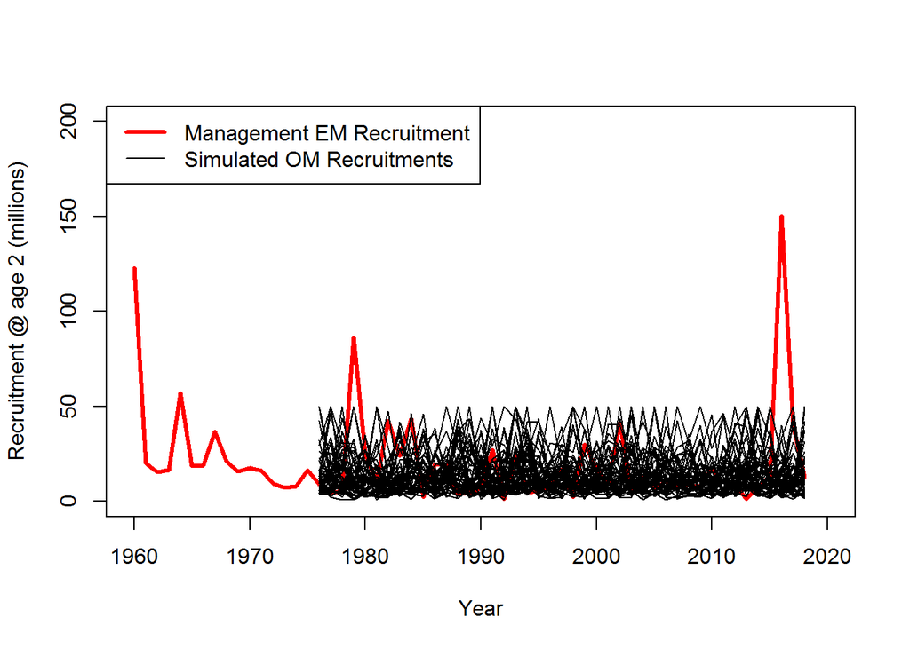

Figure 7: For comparison, the conditioning period recruitment draws for 50 simulations compared to management EM estimated recruitment is shown here, though note that these values ARE NOT USED in the conditioning period.

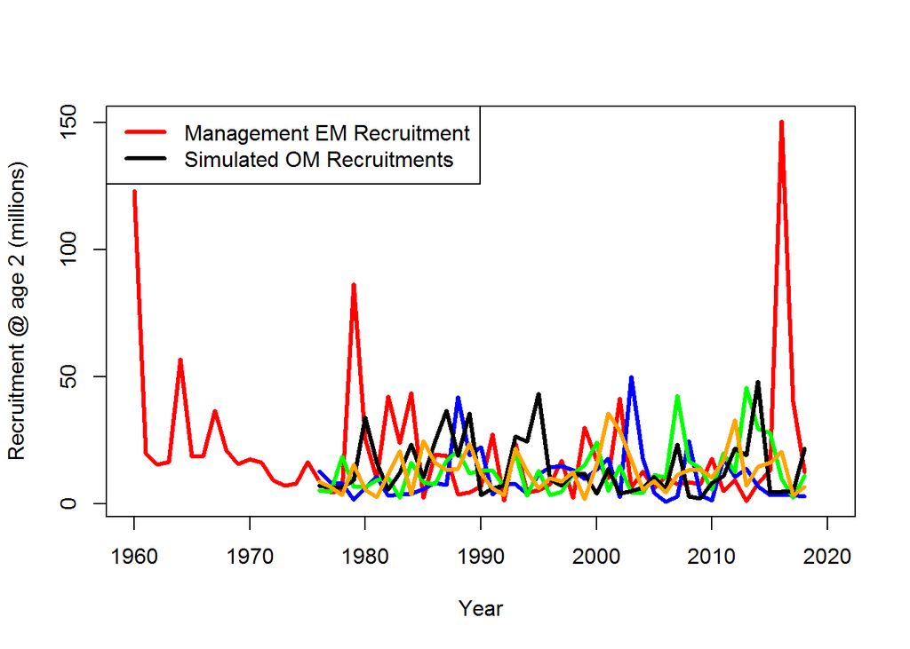

Figure 8: this shows a few individual simulations of recruitment to better view the individual variability and scale of simulated recruitment.

## Selectivity in OM

The following figures show the selectivity at age and for each area used in the OM. These are used for all years of the OM, not just the conditioning period.

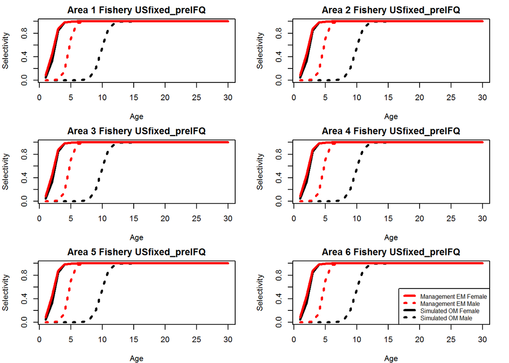

Figure 9: US fixed gear pre-IFQ selectivity for each area has a logistic form. US fixed gear pre-IFQ selectivity is sex-specific but does not differ between spatial areas; OM values are the same as the values estimated from the spatial ‘research’ EM which is under development and has been reported on in the past.

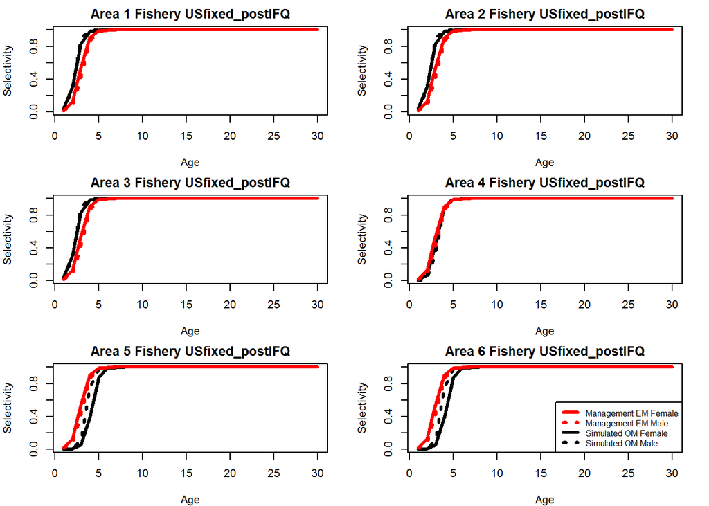

Figure 10: US fixed gear post-IFQ selectivity for each area has a logistic form. The values are sex-specific and there are some spatial differences for some areas. OM values for each area are based on the estimated selectivity values from the spatial ‘research’ EM.

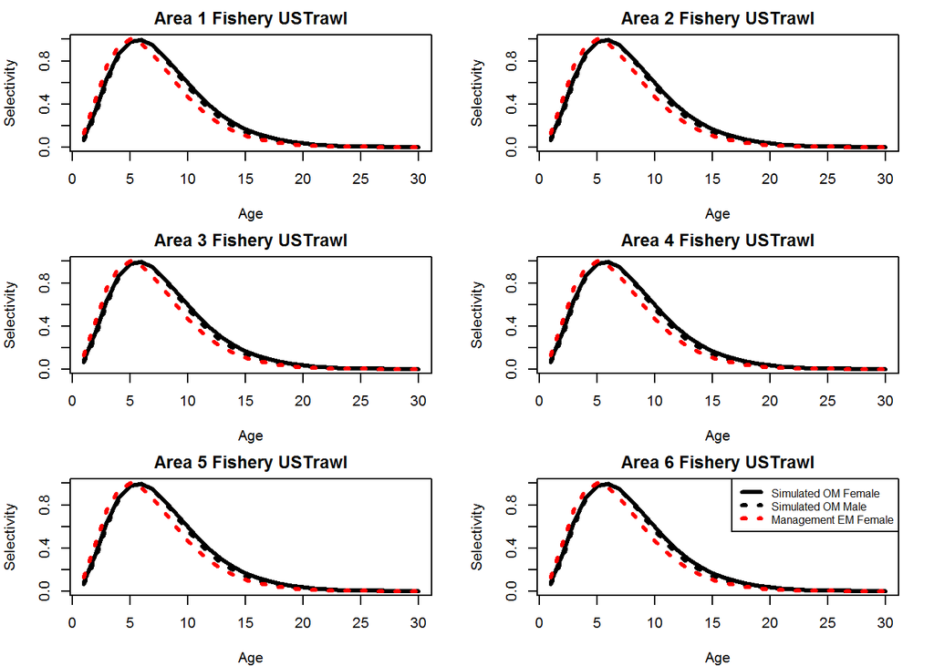

Figure 11: US trawl fishery selectivity for the OM has a domed shape. The values are sex specific and do not vary spatially. Values are from the ‘research’ spatial EM.

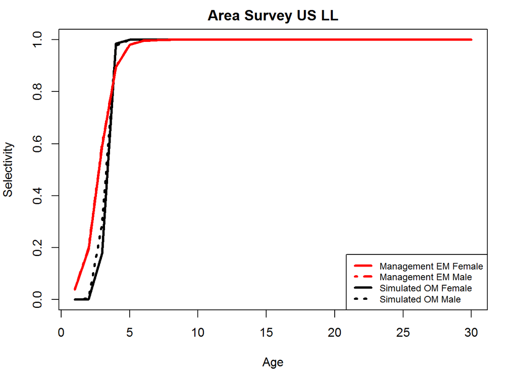

Figure 12: US longline survey selectivity parameters are not spatial but are sex specific and are based on the spatial ‘research’ EM values.

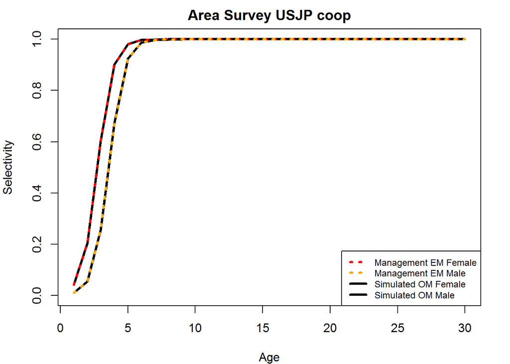

Figure 13: The USJP longline cooperative survey selectivity parameters are not spatial but are sex specific and values are based on the management EM values.

## Sampling OM population for abundance indices, age comps

The EM requires a longline survey abundance index, a fishery CPUE index, and survey and fishery age compositions. For both the conditioning period and the forward projecting period, the OM population is ‘sampled’ with logistic observation error for the indices of abundance. For each spatial area in the OM, we sample abundance for the survey and biomass for the fishery index, both with 15% sigma for observation error. Spatial areas are summed for each index, resulting in a single fishery and a single survey index. Fits to indices of abundance are shown in the next section.

Age compositions are sampled from each spatial OM regional abundance using Dirichlet multinomial error and a sample size of 200. Age compositions are combined across spatial errors (weighted by catch/survey abundance in each area) to a single set of survey and a single set of fishery age comps that are not sex specific.

# EM specifications

For 2019 onward in each annual time step, the EM is fit to data ‘sampled’ from the OM population, or to simulated population attributes with added observation error. As a reminder the order of operations for year y are: OM - Read in previous year’s apportioned ABC by area (from the EM), estimate the F required to catch ABC for each area, apply F and M to OM population, move fish between areas, sample the population for fishery and longline survey abundance indices and for longline survey and fixed gear fishery age compositions, add observation error to these data types, update the .dat file with new data for the simulation year, and fit the EM in ADMB to the updated data (.dat file), and return the EM and get an estimate of the next year’s ABC (then repeat for the next year).

## Forward looping model output

### EM Convergence

First, we look at the proportion of years within a simulation and apportionment scenario which converged. Non-converged models/years/sims ARE NOT removed from the following analyses. For these simulations, a model was considered ‘converged’ for a given year if the max gradient component was < 0.01. It is important to note that in the real world, a stock assessment scientist would have several options for improving convergence, first and foremost by iteratively adjusting both starting values and estimation phase for key model parameters. Non-convergence in this simulation exercise may be resulting from specific iterations (alternative states of nature) wherein the sablefish population is outside the range of what has been observed historically and where manual tuning of the EM would be required, a process that has not been replicated here.

Table 3. The proportion of simulations which converged for each year for each apportionment method.

```
##    Equal Fixed
## 44  0.72  0.72
## 45  0.76  0.74
## 46  0.72  0.70
## 47  0.68  0.68
## 48  0.78  0.62
## 49  0.68  0.72
## 50  0.68  0.62
## 51  0.78  0.70
## 52  0.70  0.68
## 53  0.84  0.76
## 54  0.84  0.76
```

Table 4. The overall proportion of years and simulations that converged for each apportionment method.

```
##     Equal     Fixed
## 0.7436364 0.7000000
```

### Objective function values for EM

Table 5. The percentage of years and simulations which resulted in a crashed model (‘nan’ for the objective function value) for each apportionment method.

```
## Equal Fixed
##  0.01  0.05
```

### EM Selectivity

#### Longline fishery Post-IFQ

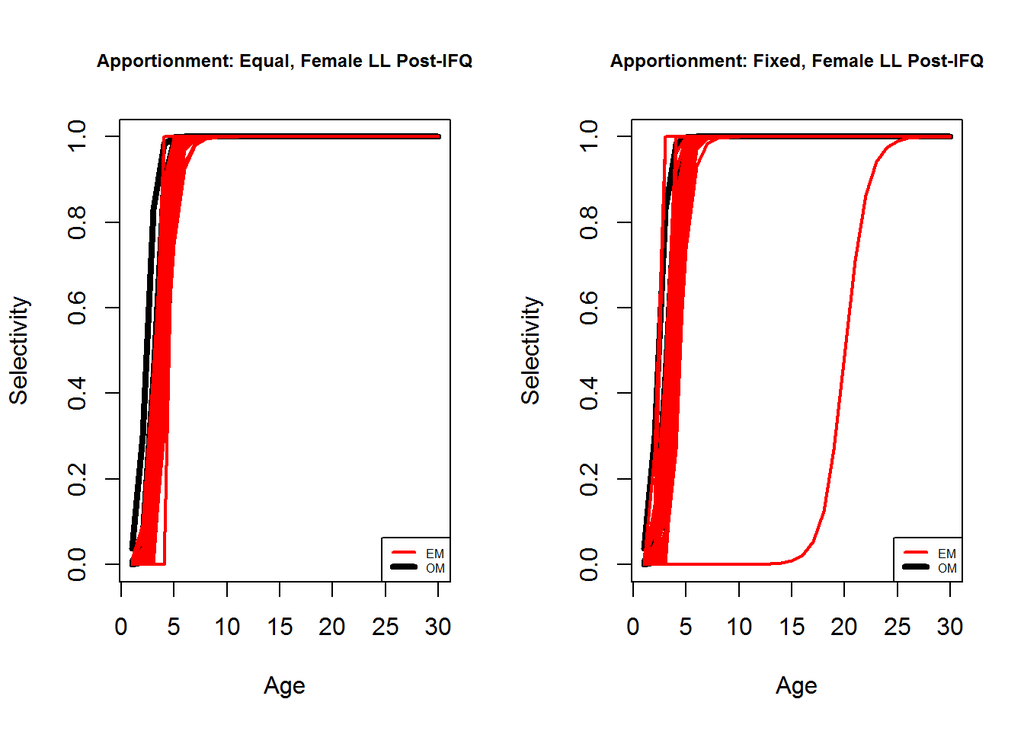

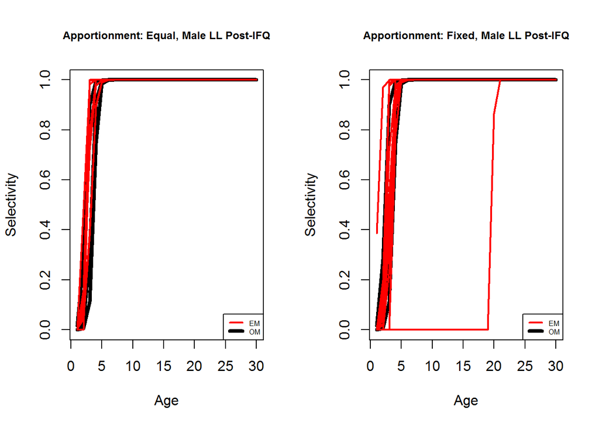

Figure 14. EM estimated selectivity for the longline fishery, Post-IFQ years for each sex and apportionment method. Each red line in a single figure panel represents a different simulation and year. Selectivity does differ over some spatial areas in the OM, but cannot be estimated spatially in the single-area EM.

#### Longline survey

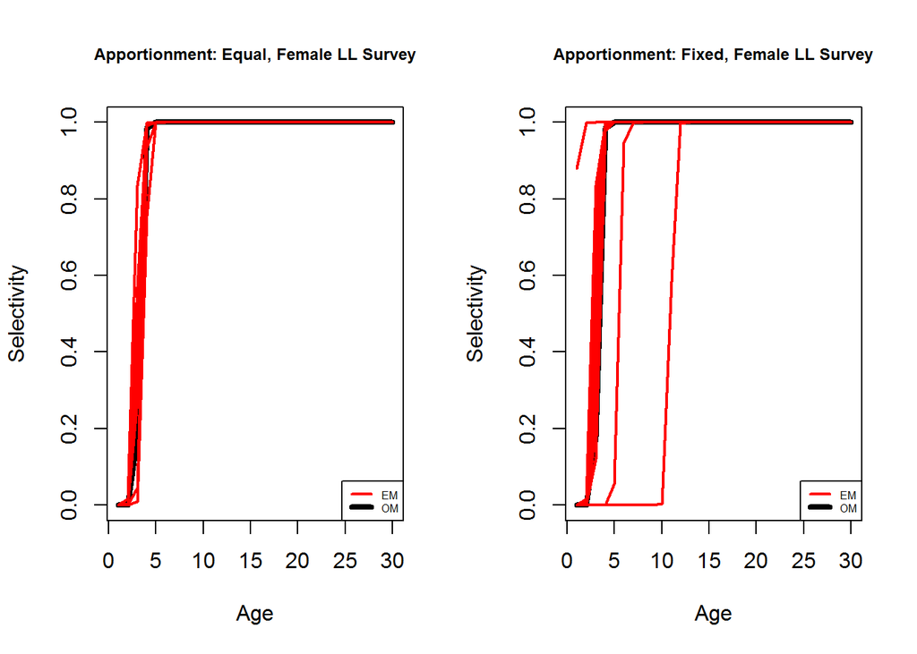

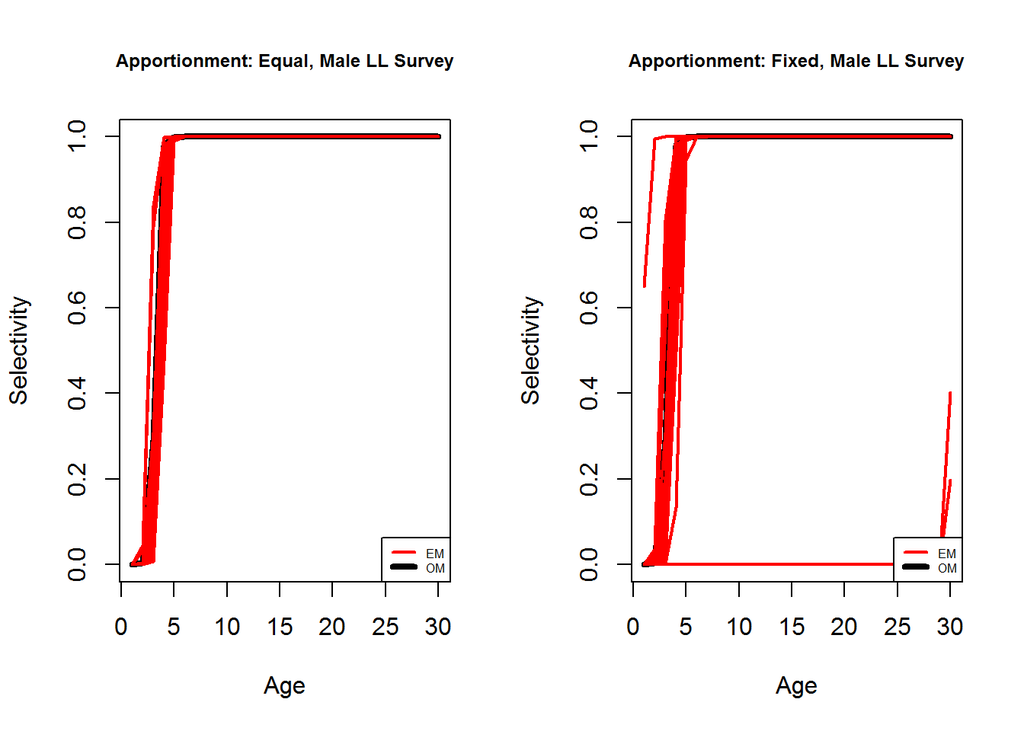

Figure 15. EM estimated selectivity for the longline survey, for each sex and apportionment method. Each red line in a single figure panel represents a different simulation and year. Selectivity does not differ over spatial areas in the OM.

### Catchability

The distribution of catchability (q) parameter estimates from the EM is shown below as boxplots. For each apportionment option (x axis) the box shows the median (thick line inside the box) and the 25th and 75th percentile interquartile range (box lower and upper border) of EM q estimates across all years and simulations. The vertical bars represent the largest and smallest values within 1.5 times the interquartile range, and any values outside these ranges are shown as points. The red line is the OM value of catchability.

#### Fixed gear fishery, foreign years

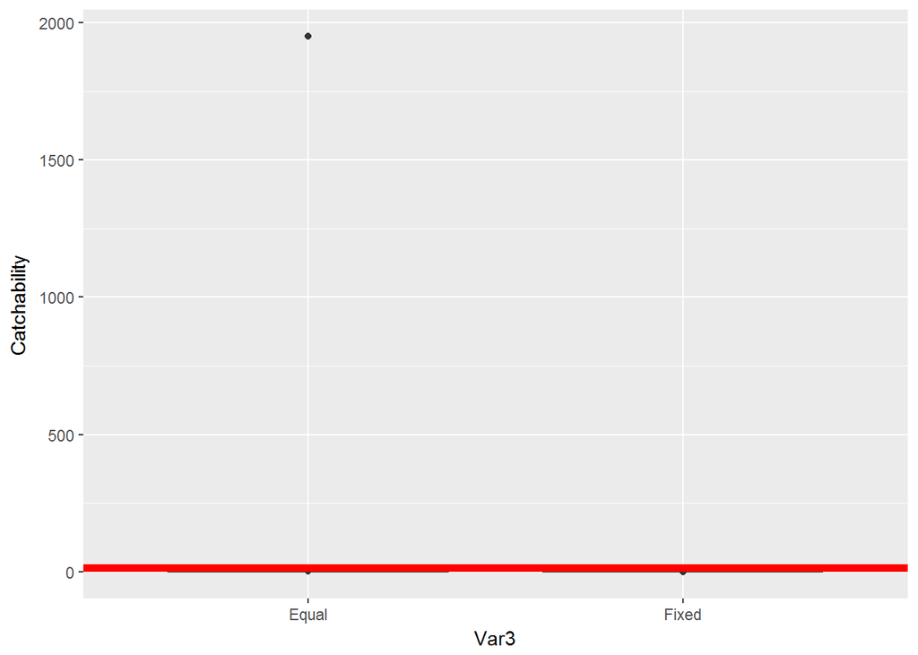

[output not shown]

Figure 16. Catchability (q) parameter estimates from the EM (black) for each apportionment method. The red line is the OM value of q.

#### Longline fishery Pre-IFQ

For the boxplots below, the dashed red line is OM q for BS, AI, and WG. The solid red line is OM q for CG, and the dotted line is OM q for WY and EY/SEO.

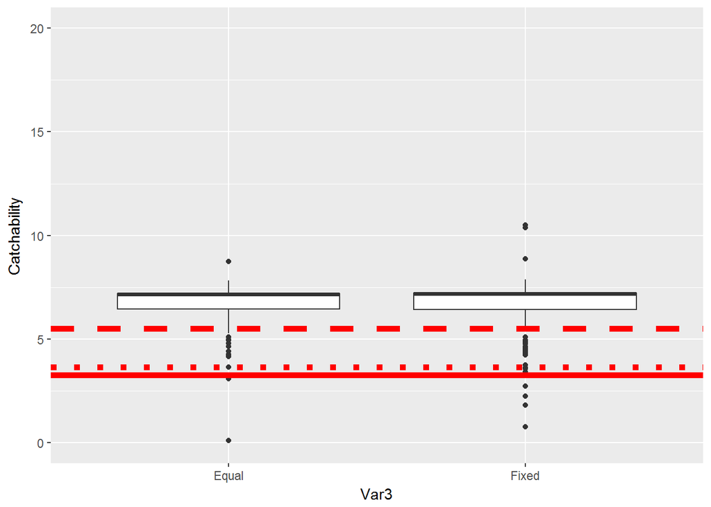

Figure 17. Catchability (q) parameter estimates from the EM (black) for each apportionment method. The red line is the OM value of q.

#### Longline fishery Post-IFQ

For the boxplots below, the dashed red line is OM q for BS, AI, and WG. The solid red line is OM q for CG, and the dotted line is OM q for WY and EY/SEO.

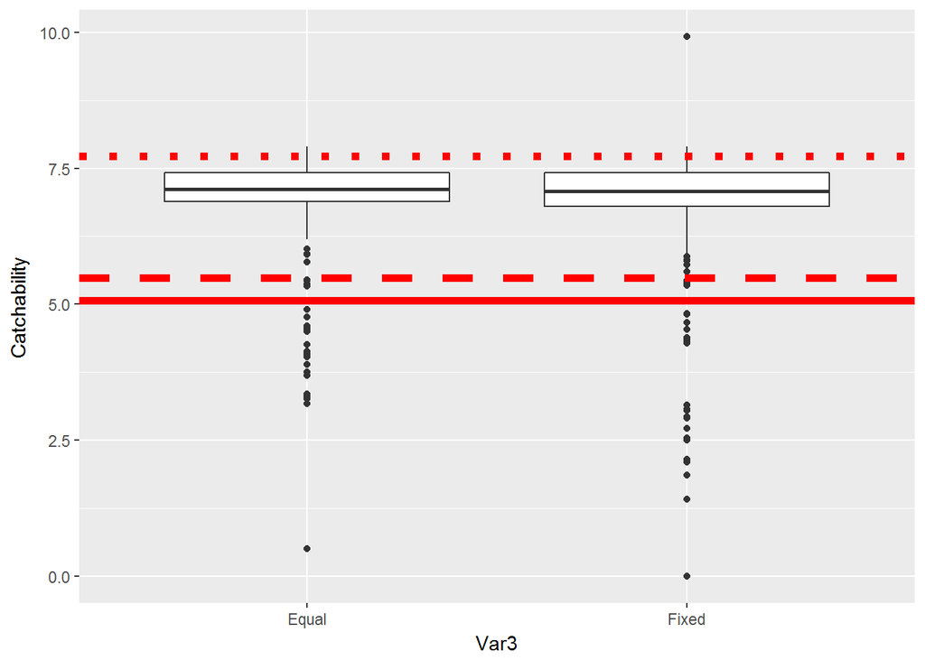

Figure 18. Catchability (q) parameter estimates from the EM (black) for each apportionment method. The red line is the OM value of q.

#### Longline survey (US years)

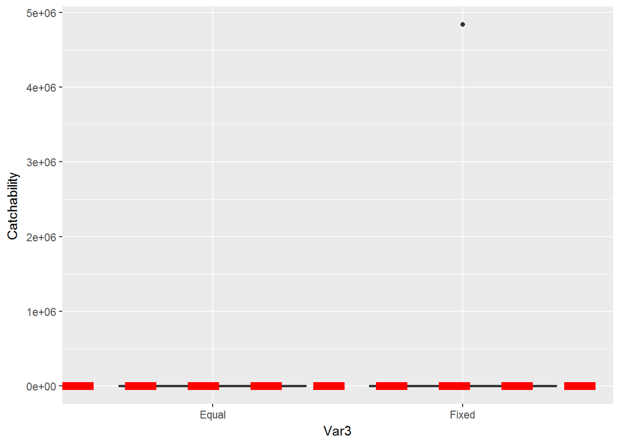

[output not shown]

Figure 19. Catchability (q) parameter estimates from the EM (black) for each apportionment method. The red line is the OM value of q.

#### Longline survey (USJP years)

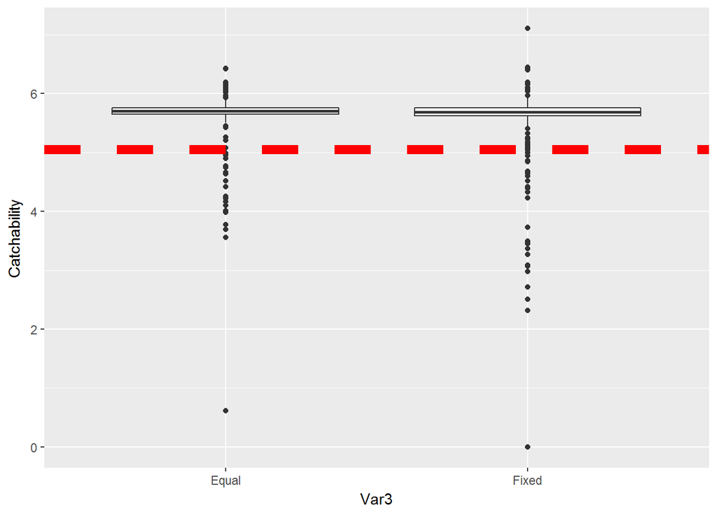

Figure 20. Catchability (q) parameter estimates from the EM (black) for each apportionment method. The red line is the OM value of q.

### Indices

#### US longline survey index (RPN)

The OM (‘true’) and EM estimates for the longline survey abundance index are shown below for each apportionment method.

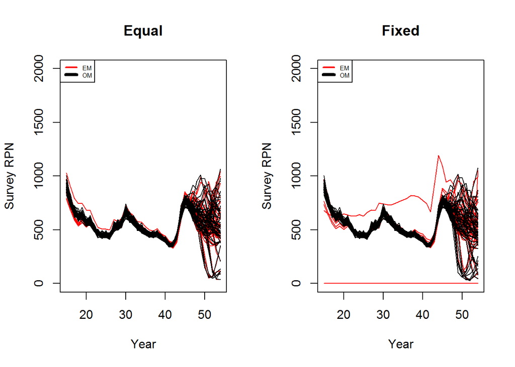

Figure 21. US longline survey indices for all years and simulations. Note that the forward projecting period begins in year 44 (2019), prior to that the Conditioning period is deterministic.

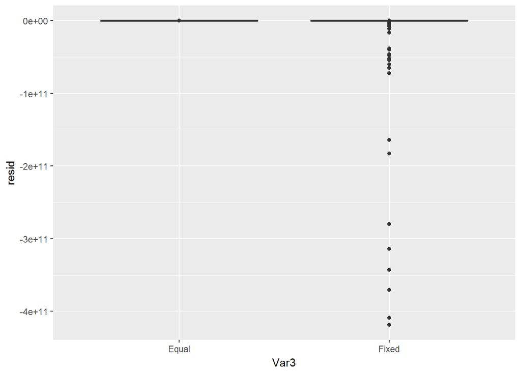

Figure 22. These boxplots are showing the residuals between the EM and OM for EM terminal year (2029) for all simulations and each apportionment method.